# HW2

Joaquin Rodriguez

9/04/2017

```r
library(tidyverse)

forbes <- read.csv(file = "Forbes2000.csv", header = T)
forbes <- as.tibble(forbes)
```

## 1. Find the median profit for the companies in the US, UK, France and Germany

```r
forbes %>%
  filter(country == c("United States","United Kingdom","France","Germany")) %>%
  group_by(country) %>%
  summarise(median = median(profits, na.rm = T))
```

```
## # A tibble: 4 x 2
##          country median
##           <fctr>  <dbl>
## 1         France  0.215
## 2        Germany  0.245
## 3 United Kingdom  0.170
## 4  United States  0.260
```

## 2. Find all German companies with negative profit

```r
forbes %>%
  filter(country == "Germany" &  profits < 0)
```

```
## # A tibble: 13 x 8
##     rank                    name country                    category sales
##    <int>                  <fctr>  <fctr>                      <fctr> <dbl>
##  1   350       Allianz Worldwide Germany                   Insurance 96.88
##  2   364        Deutsche Telekom Germany Telecommunications services 56.40
##  3   397                    E.ON Germany                   Utilities 37.95
##  4   431     HVB-HypoVereinsbank Germany                     Banking 40.52
##  5   500             Commerzbank Germany                     Banking 22.43
##  6   798   Infineon Technologies Germany              Semiconductors  7.18
##  7   869             BHW Holding Germany      Diversified financials  7.46
##  8   926 Bankgesellschaft Berlin Germany                     Banking  9.43
##  9  1034           W&W-Wustenrot Germany      Diversified financials  7.57
## 10  1187         mg technologies Germany                   Chemicals  8.54
## 11  1477 Nurnberger Beteiligungs Germany                   Insurance  3.00
## 12  1887            SPAR Handels Germany                Food markets  6.84
## 13  1994                Mobilcom Germany Telecommunications services  2.16
## # ... with 3 more variables: profits <dbl>, assets <dbl>,
## #   marketvalue <dbl>
```

## 3. Find the business category to which most of the Bermuda island companies belong

```r
forbes %>%
  filter(country == "Bermuda") %>%
  count(category) %>%
  arrange(desc(n))
```

```
## # A tibble: 9 x 2
##               category     n
##                 <fctr> <int>
## 1            Insurance    10
## 2        Conglomerates     2
## 3 Oil & gas operations     2
## 4              Banking     1
## 5        Capital goods     1
## 6 Food drink & tobacco     1
## 7         Food markets     1
## 8                Media     1
## 9  Software & services     1
```

## 4. Find the 50 companies in the Forbes dataset with the highest profit. Plot sales against assets, labelling each point with approriate country name which may need to be abbreviated (using abbreviate) to avoid makeing the plot look too messy

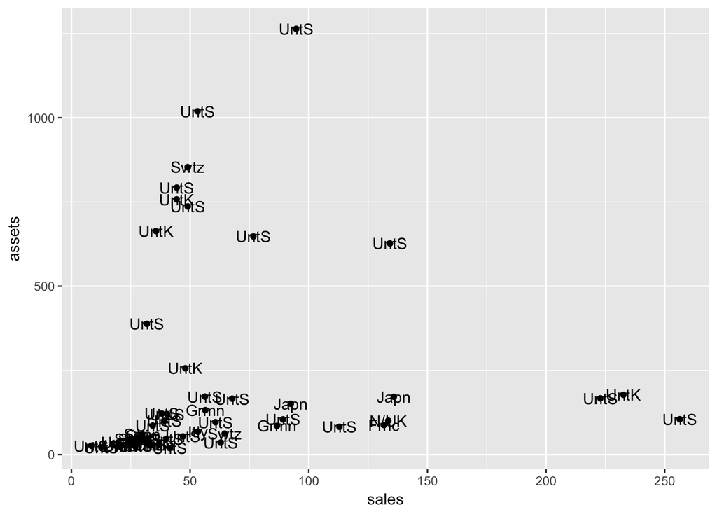

```r
forbes %>%
  arrange(desc(profits)) %>%
  top_n(50) %>%
  ggplot(aes(x = sales, y = assets)) +
  geom_point() +
  geom_text(aes(label = abbreviate(country)))
```

## 5. Find the average value of sales for the companies in each country

```r
forbes %>%
  group_by(country) %>%
  summarise(avg = mean(sales, na.rm = T)) %>%
  arrange(desc(avg))
```

```
## # A tibble: 61 x 2
##                        country      avg
##                         <fctr>    <dbl>
##  1 Netherlands/ United Kingdom 92.10000
##  2                     Germany 20.78138
##  3                      France 20.10206
##  4                 Netherlands 17.02071
##  5                       Korea 15.00500
##  6                  Luxembourg 14.18500
##  7                 Switzerland 12.45676
##  8   Australia/ United Kingdom 11.59500
##  9                      Norway 10.78000
## 10              United Kingdom 10.44511
## # ... with 51 more rows
```

## 6. Find the number of companies in each country with profits above 5 billion US dollars

```r
forbes %>%
  filter(profits > 5) %>%
  group_by(country) %>%
  count(country) %>%
  arrange(desc(n))
```

```
## # A tibble: 9 x 2
## # Groups:   country [9]
##                       country     n
##                        <fctr> <int>
## 1               United States    20
## 2                 Switzerland     3
## 3              United Kingdom     3
## 4                       China     1
## 5                      France     1
## 6                     Germany     1
## 7                       Japan     1
## 8 Netherlands/ United Kingdom     1
## 9                 South Korea     1
```

## 7. Fit a logistic regression model on the South African Heart Disease Dataset

```r
heart <-
  read.table("http://statweb.lsu.edu/faculty/li/data/SAheart.txt",
               sep=",", header=T, row.names=1) %>%
  as.tibble(.)
```

## 7.a) Set the ‘Present’ as 1 and ‘Absent’ as 0 for variable ‘famhist’.

```r
heart$famhist <-
  heart %>%
  .$famhist %>%
  recode(., "Present" = 1, "Absent" = 0)
```

## 7.b) There are 462 observations in the dataset. Randomly split the dataset into 400 observations as the training set. The rest 62 observations as the test set.

```r
train <-
  heart %>%
  sample_n(400, replace = F)

test <- setdiff(heart, train)
```

## 7.c) Then fit a logistic regression using ‘famhist’ (now become 0 and 1 binary variable) as the response and all the other variables as the explanatory variables.

```r
fit1 <-
  train %>%
  glm(formula = famhist ~ ., family = "binomial", data = .)

fit1 %>% summary
```

```
##
## Call:
## glm(formula = famhist ~ ., family = "binomial", data = .)
##
## Deviance Residuals:
##     Min       1Q   Median       3Q      Max
## -1.6512  -0.9576  -0.7090   1.0841   1.8613
##
## Coefficients:
##              Estimate Std. Error z value Pr(>|z|)
## (Intercept) -2.765454   1.143902  -2.418 0.015625 *
## sbp         -0.002797   0.005770  -0.485 0.627894
## tobacco     -0.029270   0.025867  -1.132 0.257822
## ldl          0.051330   0.056411   0.910 0.362866
## adiposity   -0.005927   0.025870  -0.229 0.818771
## typea        0.013465   0.011525   1.168 0.242670
## obesity      0.021172   0.038756   0.546 0.584856
## alcohol      0.006211   0.004402   1.411 0.158229
## age          0.025856   0.011098   2.330 0.019821 *
## chd          0.931272   0.246468   3.778 0.000158 ***
## ---
## Signif. codes:  0 '***' 0.001 '**' 0.01 '*' 0.05 '.' 0.1 ' ' 1
##
## (Dispersion parameter for binomial family taken to be 1)
##
##     Null deviance: 542.90  on 399  degrees of freedom
## Residual deviance: 501.62  on 390  degrees of freedom
## AIC: 521.62
##
## Number of Fisher Scoring iterations: 4
```

## 7.d) Make the prediction on the training and test sets. Using the 0.5 as the cutoff point to get the misclassification rate on the training and test sets, respectively.

```r
tab1 <- table(fit1$fitted.values >= 0.5, train$famhist)
tab1
```

```
##
##           0   1
##   FALSE 185  89
##   TRUE   49  77
```

```r
## misclassification rate on train set
misstrain <- 1- sum(diag(tab1)) / sum(tab1)
misstrain
```

```
## [1] 0.345
```

```r
pred1 <- predict(fit1, test, type = "response")
tab1 <- table(pred1 >= 0.5, test$famhist)
tab1
```

```
##
##          0  1
##   FALSE 26  9
##   TRUE  10 17
```

```r
## misclassification rate on test set
misstest <- 1- sum(diag(tab1)) / sum(tab1)
misstest
```

```
## [1] 0.3064516
```

## 7.e) Find the AUC score and plot the ROC curve based on the test set performance.

```r
library(AUC)
auc(roc(pred1, factor(test$famhist)))
```

```
## [1] 0.7446581
```

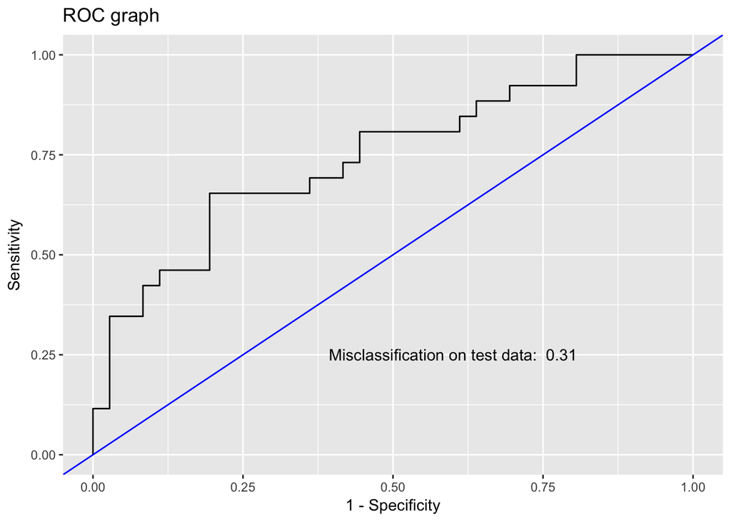

```r
roc <-
  pred1 %>%
  specificity(., factor(test$famhist)) %>%
  .$measure %>%
  as.tibble()
names(roc) <- c("spe1")

roc <-
  roc %>%
  mutate(sen1 = sensitivity(pred1, factor(test$famhist))$measure)

roc %>%
  ggplot() +
  geom_line(aes(x = 1-spe1, y = sen1)) +
  labs(x = "1 - Specificity", y = "Sensitivity", title = "ROC graph") +
  annotate("text", x = 0.6, y = 0.25, label = paste("Misclassification on test data: ", round(misstest,2))) +
  geom_abline(intercept = 0, slope = 1, color = "blue")
```